# US International Flight Data : Group 4

Amit Shendge, Disha Kacha, Rachel Culbreath, Saniya Shinde

2023-10-26

## Introduction

The data set our team has selected to focus on is Airline data from 1990-2020. This data set came from kaggle and our group made adaptations in order to amylase the data. Our group selected this data set because we were interested in the way airline data affects all the members of our group. In order to travel home we all have to rely on airline services and want to gain a comprehensive understanding of how airline traffic has changed over the years. This dataset includes a comprehensive analysis of airline traffic that focuses on flights that departed from U.S. gateways. Our group decided to subset the data and focus on the years 2011 through 2020 as this cleaned data allowed us to better analyze the data without there being too many data entries. The data highlights the airplane’s departure information including the month, day, year, usg_apt, usg_wac, fg_apt_id, fg_apt, fg_wac, and airlineid. Through these data points we are able to create smart questions that allow us to analyze how the air traffic operates, how it changes, and what we can infer about air traffic with the given data. The analysis of our data included plots, graphs, and calculations that allowed us to gain a comprehensive understanding of the airline traffic.

```r
us_flight_data<-read.csv("International_Report_Departures_Project_1.csv")
str(us_flight_data)
```

```
## 'data.frame':    332998 obs. of  16 variables:
##  $ data_dte    : chr  "4/1/12" "1/1/11" "9/1/11" "4/1/13" ...
##  $ Year        : int  2012 2011 2011 2013 2012 2012 2012 2012 2013 2011 ...
##  $ Month       : int  4 1 9 4 1 9 8 1 2 6 ...
##  $ usg_apt_id  : int  13303 10372 13303 11630 11259 13930 12266 13303 12197 14307 ...
##  $ usg_apt     : chr  "MIA" "ASE" "MIA" "FAI" ...
##  $ usg_wac     : int  33 82 33 1 74 41 74 33 22 13 ...
##  $ fg_apt_id   : int  13218 16271 11874 16049 16271 15718 16293 10711 11628 12900 ...
##  $ fg_apt      : chr  "MDE" "YYZ" "GDL" "YEV" ...
##  $ fg_wac      : int  327 936 148 931 936 467 148 327 493 427 ...
##  $ airlineid   : int  20308 21437 20149 20327 20402 20377 20447 19874 21186 21160 ...
##  $ carrier     : chr  "WE" "13Q" "PRQ" "7H" ...
##  $ carriergroup: int  1 0 1 1 1 1 1 1 0 0 ...
##  $ type        : chr  "Departures" "Departures" "Departures" "Departures" ...
##  $ Scheduled   : int  0 0 0 0 0 0 0 0 0 0 ...
##  $ Charter     : int  12 1 1 1 1 1 1 16 2 1 ...
##  $ Total       : int  12 1 1 1 1 1 1 16 2 1 ...
```

```r
us_flight_data <- us_flight_data[order(us_flight_data$Year,us_flight_data$Month),]
```

## Total Number of Flights Per Season

**We have analyzed the total number of flights per season. Firstly, we calculate the total number of flights per month each year. Then, the total number of flights per season is calculated which is then plotted using a bar chart.**

```r
departures_each_month <- aggregate(data_dte ~ Year + Month, data = us_flight_data, FUN = length)
colnames(departures_each_month) <- c("Year","Month","Total_Flights")
```

```r
season_data <- departures_each_month %>%
      mutate(Season = case_when(departures_each_month$Month %in% c(12,1,2) ~ 'Winter',                                       departures_each_month$Month %in% c(3,4,5) ~ 'Spring',
                                departures_each_month$Month %in% c(6,7,8) ~ 'Summer',
                                departures_each_month$Month %in% c(9,10,11) ~ 'Fall'))

departure_each_season <- aggregate(Total_Flights ~ Year + Season, data = season_data, FUN = sum)
```

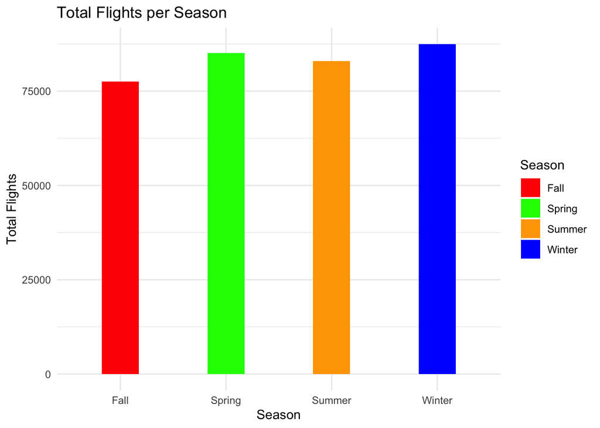

```r
library(ggplot2)

ggplot(departure_each_season, aes(x = Season, y = Total_Flights, fill = Season)) +
  geom_bar(stat = "identity", width = 0.35) +
  labs(x = "Season", y = "Total Flights", title = "Total Flights per Season") +
  scale_fill_manual(values = c("Winter" = "blue", "Spring" = "green", "Summer" = "orange", "Fall" = "red")) +
  theme_minimal()
```

**In the graph provided below, we have curated data by extracting values from both the ‘USA gate’ and ‘Foreign gate’ columns while including the most frequently occurring pairs. To illustrate this data, we have chosen a line graph as our visualization method, as depicted in the figure.** **Our aim in this analysis is to focus on the more common pairings between USA and foreign gates, thereby shedding light on more obvious patterns and relationships in the data.**

```r
top_carrier_df <- us_flight_data %>% group_by(carrier)%>%
  summarise(a_sum=length(carrier))
top_carrier_df <- top_carrier_df[order(-top_carrier_df$a_sum),]%>% top_n(5)

airports <- read.csv("Airport_Codes.csv")

us_flight_data <- merge(x = us_flight_data, y = airports, by.x="fg_apt", by.y="IATA")

carriers <- read.csv("carrier codes.csv")

us_flight_data <- merge(x = us_flight_data, y = carriers, by = "carrier")

top_carrier_df <- us_flight_data %>% group_by(Carrier_Name)%>%
  summarise(a_sum=length(Carrier_Name))
top_carrier_df <- top_carrier_df[order(-top_carrier_df$a_sum),]%>% top_n(5)
top_carrier_df <- us_flight_data %>% filter(Carrier_Name %in% top_carrier_df$Carrier_Name)
carrier_counts <- table(top_carrier_df$Carrier_Name)
top_carrier_df$Carrier_Name <- factor(top_carrier_df$Carrier_Name, levels = names(sort(carrier_counts, decreasing = TRUE)))


top_airport_df <- us_flight_data %>% group_by(Airport)%>%
  summarise(b_sum=length(Airport))
top_airport_df <- top_airport_df[order(-top_airport_df$b_sum),]%>% top_n(10)
top_airport_df <- us_flight_data %>% filter(Airport %in% top_airport_df$Airport)
Airport_counts <- table(top_airport_df$Airport)
top_airport_df$Airport <- factor(top_airport_df$Airport, levels = names(sort(Airport_counts, decreasing = TRUE)))


top_country_df <- us_flight_data %>% group_by(Country)%>%
  summarise(c_sum=length(Country))
top_country_df <- top_country_df[order(-top_country_df$c_sum),]%>% top_n(10)
top_country_df <- us_flight_data %>% filter(Country %in% top_country_df$Country)
country_counts <- table(top_country_df$Country)
top_country_df$Country <- factor(top_country_df$Country, levels = names(sort(country_counts, decreasing = TRUE)))
```

## Top 5 Carriers with highest number of flights departing from US

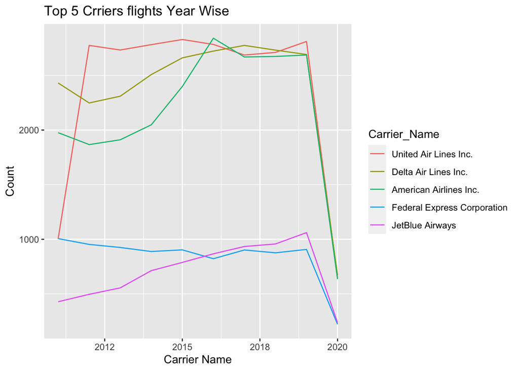

```r
library(ggrepel)
library(tidyverse)

ggplot()+geom_line(data=top_carrier_df ,
             aes(x=Year,
                 color = Carrier_Name), stat="count") + labs(title = "Top 5 Crriers flights Year Wise", x = "Carrier Name", y = "Count")
```

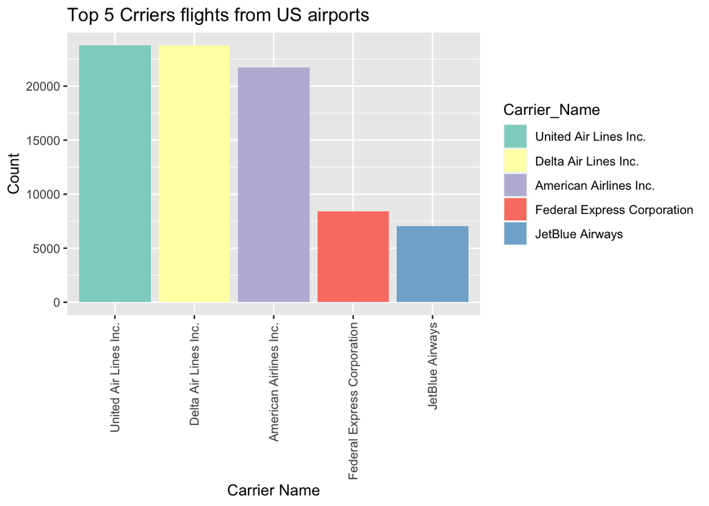

```r
ggplot(data = top_carrier_df, aes(x = Carrier_Name, fill = Carrier_Name)) +
   geom_bar() + scale_fill_brewer(palette = "Set3") + labs(title = "Top 5 Crriers flights from US airports", x = "Carrier Name", y = "Count")+ theme(axis.text.x = element_text(angle = 90, vjust = 0.5, hjust=1))
```

**The graph presents a bar chart that showcases the count of flights attended by the top five US airport carriers. The x-axis enumerates the carriers, while the y-axis represents the number of flights attended.**

**A clear visual distinction is evident between the carriers. United Airlines, Delta Airlines, and American Airlines dominate the chart with significantly higher counts, standing as the three major players in the US aviation sector. Their bars stretch considerably higher, indicating their dominant market share.**

**In stark contrast, Federal Express and JetBlue Airways have bars that are notably shorter. Their counts are less than half of what the top three airlines exhibit, underscoring their more limited operational scale in comparison.**

**The line graph over a 10-year span shows the flight trends of the top five US airport carriers. While United, Delta, and American Airlines competitively maintain their top positions, there’s a standout surge for United Airlines between 2011 and 2012, where flights skyrocket from roughly 1,000 to over 2,500, attributable to the merger with Continental Airlines in United Airlines in year 2012 Ref link- [click here](https://airwaysmag.com/continental-united-merger-completed/). Meanwhile, JetBlue Airline exhibits consistent growth, contrasting with a steady decline observed for Federal Express Airline.**

## Top 10 Countries with highest number of flights departing from US

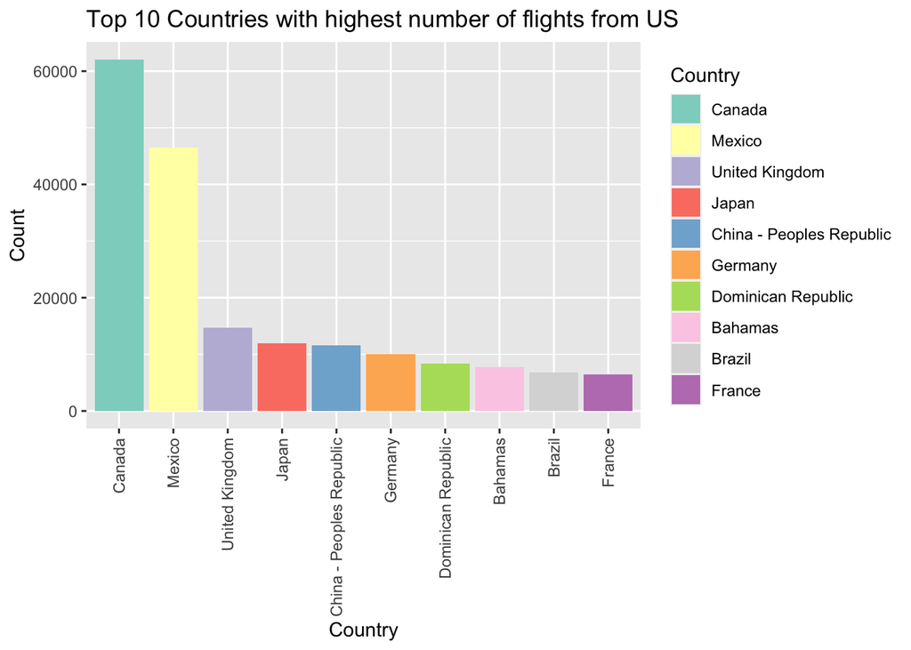

```r
ggplot(data = top_country_df, aes(x = Country, fill = Country)) +
   geom_bar() + scale_fill_brewer(palette = "Set3") + labs(title = "Top 10 Countries with highest number of flights from US", x = "Country", y = "Count")+ theme(axis.text.x = element_text(angle = 90, vjust = 0.5, hjust=1))
```

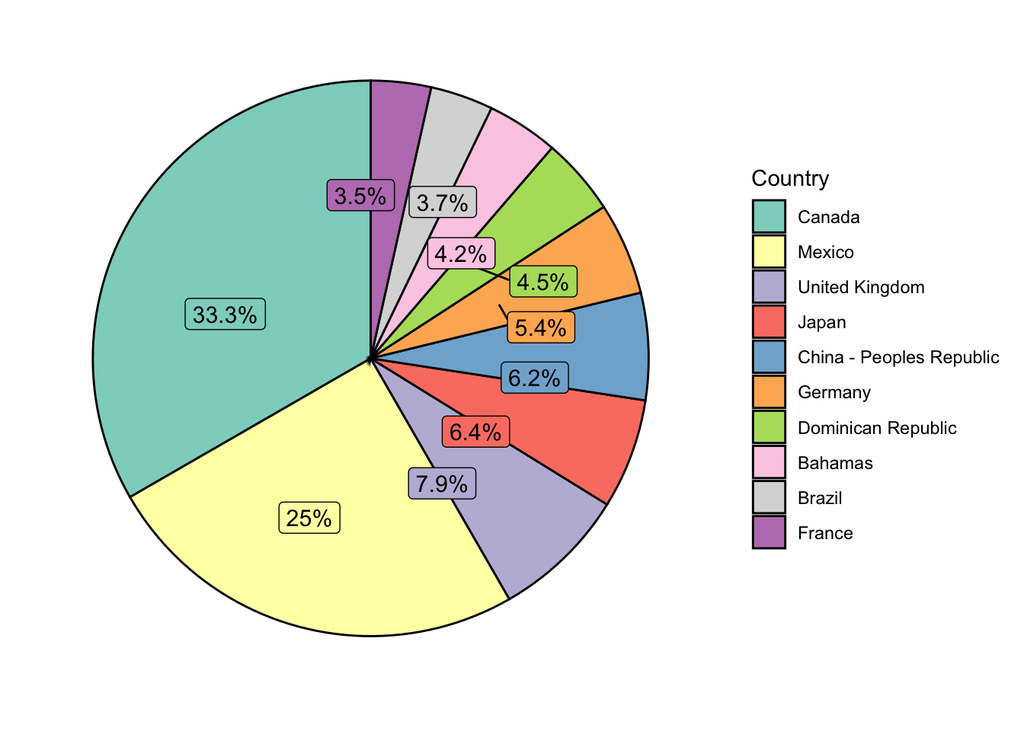

```r
top_country_df <- us_flight_data %>% group_by(Country)%>%
  summarise(c_sum=length(Country))
top_country_df <- top_country_df[order(-top_country_df$c_sum),]%>% top_n(10)

df2 <- top_country_df %>%
  mutate(csum = rev(cumsum(rev(c_sum))),
         per = round(c_sum/sum(c_sum) * 100,1),
         test='',
         pos = c_sum/2 + lead(csum, 1),
         pos = if_else(is.na(pos), c_sum/2, pos))

ggplot(top_country_df, aes(x = "", y = c_sum, fill = fct_inorder(Country))) +
  geom_col(width = 1, color = 1) +
  geom_text(aes(label = df2$test),
            position = position_stack(vjust = 0.5)) +
  coord_polar(theta = "y") +
  guides(fill = guide_legend(title = "Country")) +
  scale_y_continuous(breaks = df2$pos, labels = df2$test) +
    geom_label_repel(aes(y = df2$pos, label = paste0(df2$per, "%")), data = top_country_df, size=4, show.legend = F, nudge_x = 0) +
  theme(axis.ticks = element_blank(),
        axis.title = element_blank(),
        axis.text = element_text(size = 10),
        panel.background = element_rect(fill = "white"))+ scale_fill_brewer(palette = "Set3")
```

**The bar chart delineates the top 10 countries with the highest number of flights from the US. On the x-axis, we have the countries listed, while the y-axis quantifies the count of flights attended.**

**Canada towers above the rest with a massive count of around 60,000 flights, closely followed by Mexico with over 40,000 flights. The difference becomes stark as we move to the third spot with the UK, which has close to 15,000 flights. Beyond the UK, the flight count continues to decrease significantly for the remaining countries in the list.**

**Complementing the bar chart, the pie chart visualizes the proportion of flights to these top 10 countries from the US. Canada occupies a dominant 33.3% of the chart, reinforcing its top position in flight counts. Mexico follows with a significant 25% slice. After these two, the rest of the countries share the remaining 41.7%, with each having a noticeably smaller portion compared to Canada and Mexico.**

**Together, these charts provide a clear visual representation of the US’s international flight distribution, emphasizing the predominance of Canada and Mexico in terms of flight counts.**

## Top 10 occurences of same US and Foreign gates in pairs

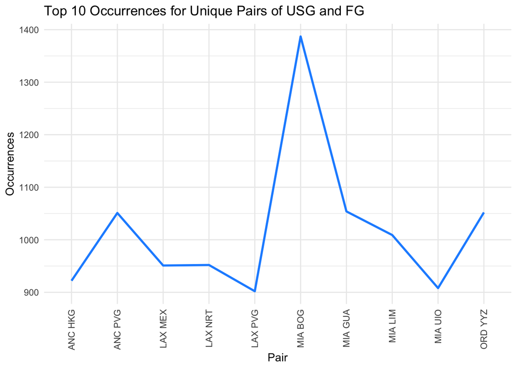

```r
# Combine the values from both columns into pairs
pairs <- paste(us_flight_data$usg_apt, us_flight_data$fg_apt)

# Calculate the occurrences of each unique pair
pair_counts <- table(pairs)

# Sort the pairs by occurrence in descending order
sorted_pairs <- names(sort(pair_counts, decreasing = TRUE))

# Select the top 10 pairs
top_10_pairs <- sorted_pairs[1:10]

# Filter the data to include only the top 10 pairs
filtered_data <-us_flight_data[pairs %in% top_10_pairs, ]

# Create a line graph for the top 10 pairs
library(ggplot2)
ggplot(data = as.data.frame(table(paste(filtered_data$usg_apt, filtered_data$fg_apt))),
       aes(x = Var1, y = Freq, group = 1)) +
  geom_line(color = "dodgerblue", size = 1) +
  labs(title = "Top 10 Occurrences for Unique Pairs of USG and FG",
       x = "Pair", y = "Occurrences") +
  theme_minimal() +
  theme(axis.text.x = element_text(angle = 90, vjust = 0.5, hjust = 1))
```

**In the presented data, the top 10 occurrences of pairs of gates for airlines were analyzed. Notably, Miami emerged as a prominent destination due to its tourist attractions, resulting in high demand for flights. The government has advised both employees and passengers to arrive early at Miami’s airport to mitigate crowds and potential delays. Other significant routes in this analysis include Chicago to Toronto and Alaska to Shanghai.**

**This analysis provides valuable insights into travel patterns and can aid in optimizing airport operations and enhancing the passenger experience. The data allows for tracking the highest number of visits based on the airline gate location and destination, aiding in resource allocation and scheduling for more efficient travel management.**

**In our analysis below, we began by converting the columns ‘carrier group’ and ‘Year’ into factors since they represent categorical variables. The conversion into factors allows us to treat these variables appropriately in our statistical analysis.**

##Checking any null values or outliers

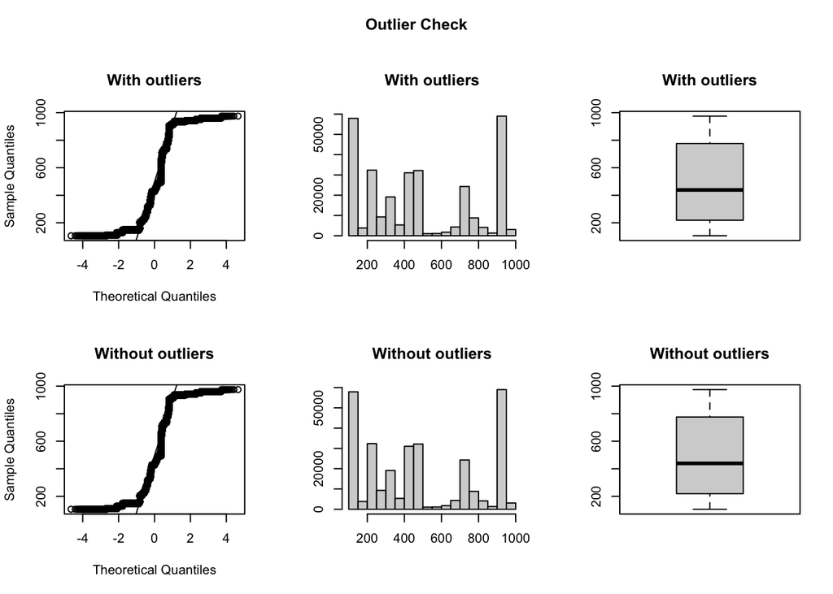

```
## Outliers identified: 0
## Proportion (%) of outliers: 0
## Mean of the outliers: NaN
## Mean without removing outliers: 492
## Mean if we remove outliers: 492
## Outliers successfully removed
```

```r
library(ezids)
library(ggplot2)
#Convert it into factor

us_flight_data$carriergroup <- factor(us_flight_data$carriergroup)
us_flight_data$Year <- factor(us_flight_data$Year)


foreign_out =outlierKD2(us_flight_data,fg_wac,rm=TRUE,boxplt=TRUE,histogram = TRUE,qqplt=TRUE)
```

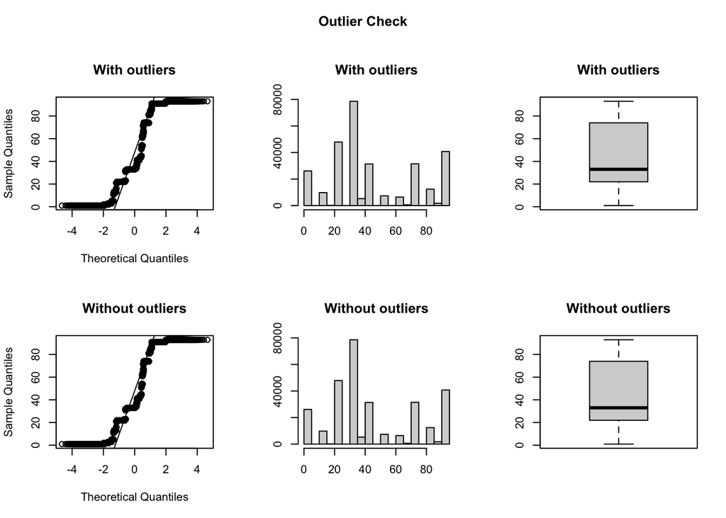

```
## Outliers identified: 0
## Proportion (%) of outliers: 0
## Mean of the outliers: NaN
## Mean without removing outliers: 44.7
## Mean if we remove outliers: 44.7
## Outliers successfully removed
```

```r
us_out =outlierKD2(foreign_out,usg_wac,rm=TRUE,boxplt=TRUE,histogram = TRUE,qqplt=TRUE)
```

```r
complete_data_changes = us_out
```

## Creating Subset of Carrier Group column

```r
foreign_carrier <- subset(complete_data_changes,complete_data_changes$carriergroup==0)

cat("Foreign Carrier are as follows:\n")
```

```
## Foreign Carrier are as follows:
```

```r
head(foreign_carrier,7)
```

```
##   carrier fg_apt data_dte Year Month usg_apt_id usg_apt usg_wac fg_apt_id
## 1     02Q    SNN   3/1/20 2020     3      12478     JFK      22     14918
## 2     02Q    DUB  10/1/13 2013    10      10721     BOS      13     11435
## 3     02Q    ARN   6/1/17 2017     6      14747     SEA      93     10357
## 4     02Q    LIM  12/1/19 2019    12      14761     SFB      33     12986
## 5     02Q    YYR   3/1/18 2018     3      12451     JAX      33     16267
## 6     02Q    STN   2/1/20 2020     2      13303     MIA      33     15018
## 7     02Q    SNN   6/1/18 2018     6      14259     PSM      14     14918
##   fg_wac airlineid carriergroup       type Scheduled Charter Total ICAO
## 1    441     21040            0 Departures         0       1     1 EINN
## 2    441     21040            0 Departures         1       0     1 EIDW
## 3    484     21040            0 Departures         0       1     1 ESSA
## 4    368     21040            0 Departures         0       1     1 SPIM
## 5    961     21040            0 Departures         0       1     1 CYYR
## 6    493     21040            0 Departures         0       1     1 EGSS
## 7    441     21040            0 Departures         0       1     1 EINN
##                  Location                 Airport        Country  Carrier_Name
## 1                 Shannon         Shannon Airport        Ireland Titan Airways
## 2                  Dublin     Dublin Intl Airport        Ireland Titan Airways
## 3               Stockholm                 Arlanda         Sweden Titan Airways
## 4             Lima-Callao       Jorge Chavez Intl           Peru Titan Airways
## 5 Goose Bay, Newfoundland                   Goose         Canada Titan Airways
## 6                  London London Stansted Airport United Kingdom Titan Airways
## 7                 Shannon         Shannon Airport        Ireland Titan Airways
```

```r
us_carrier  <- subset(complete_data_changes,complete_data_changes$carriergroup==1)

cat("US Carrier are as follows:\n")
```

```
## US Carrier are as follows:
```

```r
head(us_carrier,7)
```

```
##    carrier fg_apt data_dte Year Month usg_apt_id usg_apt usg_wac fg_apt_id
## 92     04Q    YUL   4/1/14 2014     4      10478     BAF      13     16217
## 93     04Q    LRM  10/1/19 2019    10      14843     SJU       3     13068
## 94     04Q    YTZ   4/1/12 2012     4      13232     MDW      41     16215
## 95     04Q    YOW   3/1/20 2020     3      14027     PBI      33     16149
## 96     04Q    YTZ  11/1/14 2014    11      12197     HPN      22     16215
## 97     04Q    YHM   9/1/14 2014     9      11961     GON      11     16078
## 98     04Q    YQA   8/1/16 2016     8      12197     HPN      22     16162
##    fg_wac airlineid carriergroup       type Scheduled Charter Total ICAO
## 92    941     21080            1 Departures         0       1     1 CYUL
## 93    224     21080            1 Departures         0       2     2 MDLR
## 94    936     21080            1 Departures         0       1     1 CYTZ
## 95    936     21080            1 Departures         0       1     1 CYOW
## 96    936     21080            1 Departures         0       6     6 CYTZ
## 97    936     21080            1 Departures         0       2     2 CYHM
```

[output cut: 17 more lines]

```r
contingency_table <- table(complete_data_changes$Year, complete_data_changes$carriergroup)
row_names <- c("2011", "2012", "2013", "2014", "2015", "2016","2017","2018","2019","2020")
rownames(contingency_table) <- row_names

col_names <- c("Foreign","US")
colnames(contingency_table) <- col_names

xkabledply(contingency_table, title="Contingency table")
```

Contingency table

|  | Foreign | US |
| --- | --- | --- |
| 2011 | 11629 | 14431 |
| 2012 | 11696 | 16289 |
| 2013 | 11774 | 16368 |
| 2014 | 12071 | 17761 |
| 2015 | 13637 | 18824 |
| 2016 | 15044 | 19797 |
| 2017 | 16500 | 20409 |
| 2018 | 17394 | 20585 |
| 2019 | 16895 | 19729 |
| 2020 | 4256 | 4875 |

**A statistical test for determining the independence or correlation between two or more categorical variables in a contingency table is the chi-square test. By comparing the observed frequencies of the categories to the predicted frequencies in the absence of any link, or if the variables were independent, it is possible to ascertain whether or not there is a significant relationship between these categorical variables.**

**There are two primary formats for the chi-square test:**

**The purpose of the Chi-Square Test of Independence is to ascertain if two categorical variables significantly depend on one another or have a connection. While the alternative hypothesis (Ha) contends that the two variables are dependent, the null hypothesis (H0) holds that they are independent.**

**The Chi-Square Goodness-of-Fit Test evaluates how well the observed frequencies in a single category variable correspond to a given distribution, often an anticipated distribution. It examines if the observed data conforms to the distribution that was predicted.**

## Chi-Square test using Year and Carrier Group

```r
contingency_table <- table(complete_data_changes$Year, complete_data_changes$carriergroup)

chi_squared_test <- chisq.test(contingency_table)


print(chi_squared_test)
```

```
##
##  Pearson's Chi-squared test
##
## data:  contingency_table
## X-squared = 461, df = 9, p-value <2e-16
```

**Degrees of Freedom (df): df = 9 in your case. The number of degrees of freedom utilized in the chi-square distribution is represented by degrees of freedom. The number of categories in the variables under analysis determines how it is calculated. In this instance, df = 9 indicates that the chi-square distribution has nine degrees of freedom.**

**p-value: < 2.2e-16: An important result of the chi-square test is the p-value. Given the assumption of independence, it shows the likelihood of observing the data. The p-value in your example is p < 0.001, which is very small, almost equal to zero. This indicates that, given the null hypothesis of independence, it is extremely unlikely that the observed data happened by accident. Consequently, you would normally come to the conclusion that there is a statistically significant association between the variables and reject the null hypothesis.**

**In conclusion, the data shows that the variables under study have a substantial and statistically significant relationship. The remarkably small p-value (< 0.001) and the large chi-square statistic (X-squared) indicate that there is a significant deviation between the observed data and the expected value if the variables were independent. The test’s chi-square distribution can be learned more about from the degrees of freedom (df).**

## Total Number of Flights Per Carrier

```r
total_flights <- aggregate(Total ~ Year + carriergroup, us_flight_data, sum)
```

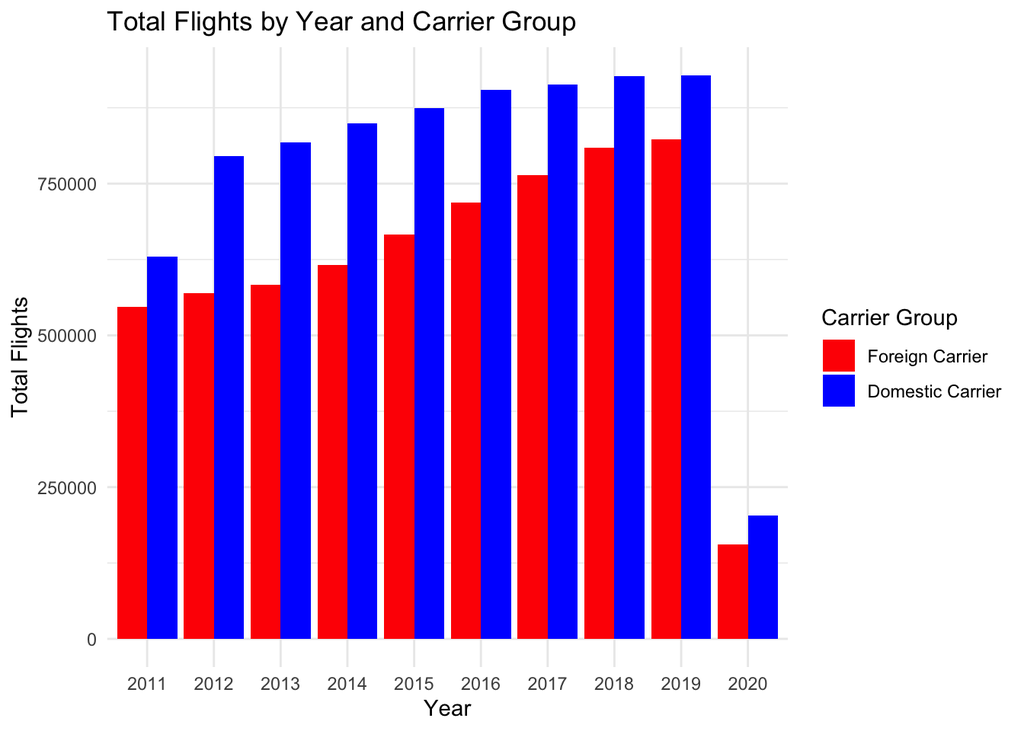

```r
ggplot(total_flights, aes(x = factor(Year), y = Total, fill = factor(carriergroup))) +
       geom_bar(stat = "identity",position = "dodge") +
      labs(x = "Year", y = "Total Flights", title = "Total Flights by Year and Carrier Group") +
      scale_fill_manual(values = c("0" = "red", "1" = "blue"),
                labels = c("Foreign Carrier", "Domestic Carrier"),
                       name = "Carrier Group") +
      theme_minimal()
```

**The bar chart above shows the total number of flight of domestic and foreign carriers for each year. We can see that the total number of flights of domestic carriers than foreign carriers for each year. This maybe because domestic carriers have well established infrastructure at various airports across the country, making it easier for them to operate more flights. Also, domestic carriers have lower operational costs within USA as compared to foreign carriers.**

```r
library(dplyr)
library(ggplot2)
library(ezids)
library(RColorBrewer)
```

## Year Plot

```r
year <- us_flight_data[order(us_flight_data$Year,us_flight_data$Month),]
```

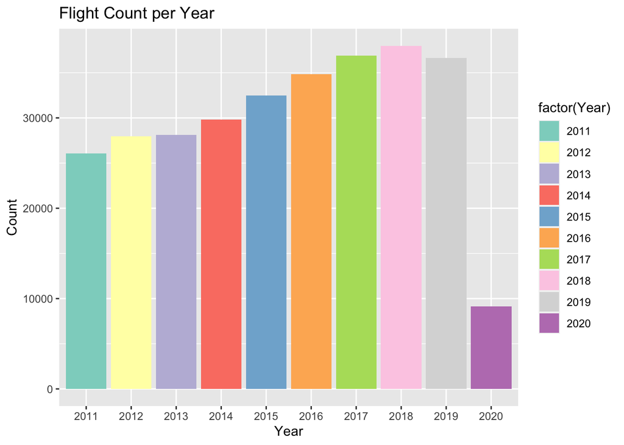

```r
ggplot(data = year, aes(x = factor(Year), fill = factor(Year))) +
   geom_bar() + scale_fill_brewer(palette = "Set3") + labs(title = "Flight Count per Year", x = "Year", y = "Count")
```

```r
mx <- max(year$usg_apt)
print(mx)
```

```
## [1] "ZZZ"
```

```r
mn <- min(year$usg_apt)
print(mn)
```

```
## [1] "1B1"
```

```r
dta2011 <- subset(year, Year == '2011')
count(dta2011)
```

```
##       n
## 1 26060
```

```r
dta2012 <- subset(year, Year == '2012')
count(dta2012)
```

```
##       n
## 1 27985
```

```r
dta2013 <- subset(year, Year == '2013')
count(dta2013)
```

```
##       n
## 1 28142
```

```r
dta2014 <- subset(year, Year == '2014')
count(dta2014)
```

```
##       n
## 1 29832
```

```r
dta2015 <- subset(year, Year == '2015')
count(dta2015)
```

```
##       n
## 1 32461
```

```r
dta2016 <- subset(year, Year == '2016')
count(dta2016)
```

```
##       n
## 1 34841
```

```r
dta2017 <- subset(year, Year == '2017')
count(dta2017)
```

```
##       n
## 1 36909
```

```r
dta2018 <- subset(year, Year == '2018')
count(dta2018)
```

```
##       n
## 1 37979
```

```r
dta2019 <- subset(year, Year == '2019')
count(dta2019)
```

```
##       n
## 1 36624
```

```r
dta2020 <- subset(year, Year == '2020')
count(dta2020)
```

```
##      n
## 1 9131
```

A t test was preformed in order to see if the values can be compared. The values we have selected to compare are flight months and schedules in 2018 and flight months and schedules in 2016. Through analysis of the t-test we are able to see there are slight differences in the mean of the data for the years in question. This data allows use to get a better understanding of what we are looking at and we can infer that one data set is larger than the other as this will affect the mean of the data set.

```r
t2 = t.test(dta2018$Scheduled, conf.level = 0.05)
print(t2)
```

```
##
##  One Sample t-test
##
## data:  dta2018$Scheduled
## t = 146, df = 37978, p-value <2e-16
## alternative hypothesis: true mean is not equal to 0
## 5 percent confidence interval:
##  44.4 44.4
## sample estimates:
## mean of x
##      44.4
```

```r
m2 = t.test(dta2018$Month, conf.level = 0.05)
print(m2)
```

```
##
##  One Sample t-test
##
## data:  dta2018$Month
## t = 365, df = 37978, p-value <2e-16
## alternative hypothesis: true mean is not equal to 0
## 5 percent confidence interval:
##  6.44 6.44
## sample estimates:
## mean of x
##      6.44
```

```r
t6 = t.test(dta2016$Scheduled, conf.level = 0.05)
print(t6)
```

```
##
##  One Sample t-test
##
## data:  dta2016$Scheduled
## t = 141, df = 34840, p-value <2e-16
## alternative hypothesis: true mean is not equal to 0
## 5 percent confidence interval:
##  45.4 45.4
## sample estimates:
## mean of x
##      45.4
```

```r
m6 = t.test(dta2016$Month, conf.level = 0.05)
print(m6)
```

```
##
##  One Sample t-test
##
## data:  dta2016$Month
## t = 353, df = 34840, p-value <2e-16
## alternative hypothesis: true mean is not equal to 0
## 5 percent confidence interval:
##  6.53 6.53
## sample estimates:
## mean of x
##      6.53
```

```r
mxairport <- subset(year, usg_apt == 'ZZZ')
#print(mxairport)

minairport <- subset(year, usg_apt == '1B1')
#print(minairport)

mxcount <- count(mxairport)
mincount <- count(minairport)
print(mxcount)
```

```
##     n
## 1 192
```

```r
print(mincount)
```

```
##   n
## 1 2
```

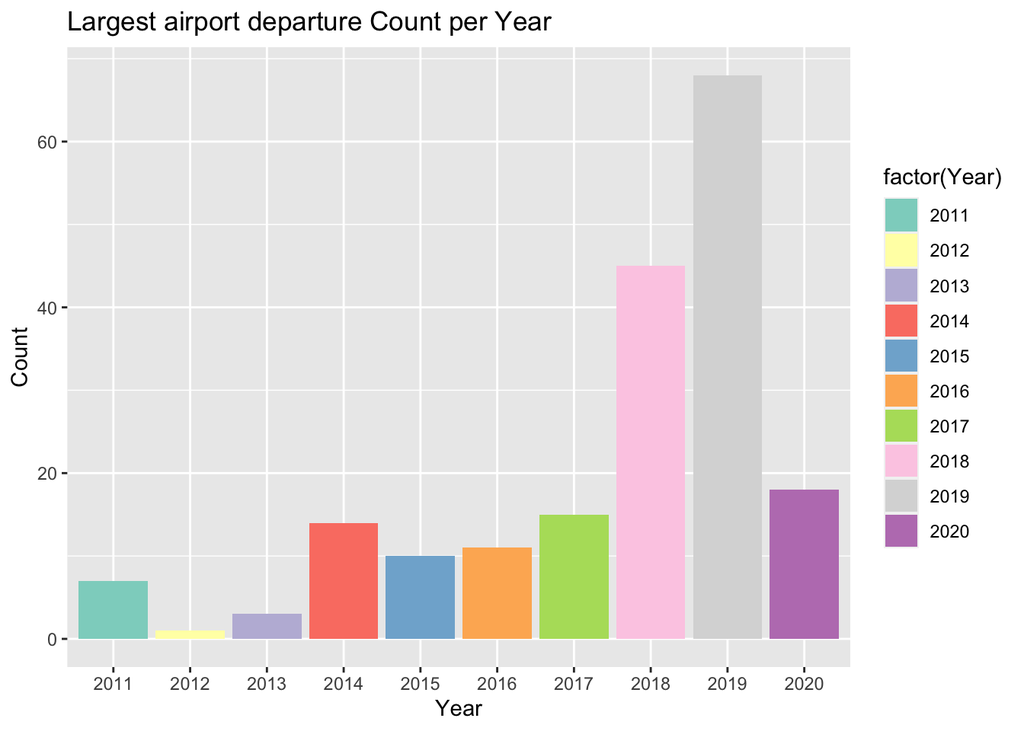

```r
ggplot(data = mxairport, aes(x = factor(Year), fill = factor(Year))) +
   geom_bar() + scale_fill_brewer(palette = "Set3") + labs(title = "Largest airport departure Count per Year", x = "Year", y = "Count")
```

A chi squared test was preformed to infer if year and usg_apt are independent variables or if they are dependent on each other.

```r
chisq.test(year$Year, year$usg_apt)
```

```
##
##  Pearson's Chi-squared test
##
## data:  year$Year and year$usg_apt
## X-squared = 18536, df = 6363, p-value <2e-16
```

## Conclusion

**We found that flight patterns are far from static. They evolve over time, influenced by a multitude of factors such as seasonality, geography, and the choices of both passengers and airlines. The data has allowed us to map out the intricate web of flight routes and the regions of highest aviation activity, offering a unique perspective on the industry’s flow.**

**Seasonal variations were evident, emphasizing the critical role that weather, holidays, and other seasonal factors play in shaping the aviation landscape. We also gained a profound understanding of the airports that served as crucial nodes in this intricate network, with major hubs and regional airports playing distinct roles in the travel ecosystem.**

**Furthermore, the analysis of airline data has enabled us to discern market dynamics, customer preferences, and the competitive forces that drive the industry forward. The insights gained from this data offer valuable information for aviation companies, policymakers, and travelers alike.**

## Future Scope

**Looking ahead, our research is poised for further expansion and depth. The next phase of our investigation involves gathering and analyzing data from the post-pandemic period, commencing in 2020. This expansion into the recent years presents an exciting opportunity to evaluate how the aviation industry has coped with the unparalleled challenges brought about by the global pandemic.**

**We aim to explore and document the profound impacts of the pandemic on the aviation sector. This includes understanding how airlines have adapted to the new normal, how passenger behavior has evolved, and the extent of the industry’s recovery efforts. Our research will provide a holistic view of the transformations in the aviation industry, yielding insights that are relevant to not only industry stakeholders but also to the broader public and policymakers.**